# Homework 1

This is a quarto document for Homework 1. I just messed with a perfectly good submission.

```r
library(tidyverse)
mtcars %>% summary
```

```
      mpg             cyl             disp             hp
 Min.   :10.40   Min.   :4.000   Min.   : 71.1   Min.   : 52.0
 1st Qu.:15.43   1st Qu.:4.000   1st Qu.:120.8   1st Qu.: 96.5
 Median :19.20   Median :6.000   Median :196.3   Median :123.0
 Mean   :20.09   Mean   :6.188   Mean   :230.7   Mean   :146.7
 3rd Qu.:22.80   3rd Qu.:8.000   3rd Qu.:326.0   3rd Qu.:180.0
 Max.   :33.90   Max.   :8.000   Max.   :472.0   Max.   :335.0
      drat             wt             qsec             vs
 Min.   :2.760   Min.   :1.513   Min.   :14.50   Min.   :0.0000
 1st Qu.:3.080   1st Qu.:2.581   1st Qu.:16.89   1st Qu.:0.0000
 Median :3.695   Median :3.325   Median :17.71   Median :0.0000
 Mean   :3.597   Mean   :3.217   Mean   :17.85   Mean   :0.4375
 3rd Qu.:3.920   3rd Qu.:3.610   3rd Qu.:18.90   3rd Qu.:1.0000
 Max.   :4.930   Max.   :5.424   Max.   :22.90   Max.   :1.0000
       am              gear            carb
 Min.   :0.0000   Min.   :3.000   Min.   :1.000
 1st Qu.:0.0000   1st Qu.:3.000   1st Qu.:2.000
 Median :0.0000   Median :4.000   Median :2.000
 Mean   :0.4062   Mean   :3.688   Mean   :2.812
 3rd Qu.:1.0000   3rd Qu.:4.000   3rd Qu.:4.000
 Max.   :1.0000   Max.   :5.000   Max.   :8.000
```

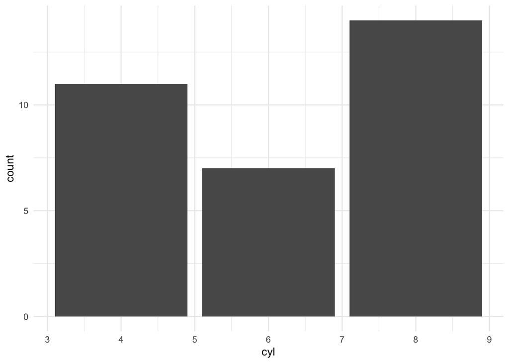

```r
mtcars %>% ggplot() + aes(x=cyl) + geom_bar() + theme_minimal()
```

I created a temporary github account to pull this off in an example. If you want to look over the commit history, this is basically what I had in mind. I should point out that, unless I wanted to go back and forth across two computers, I have to do some of the editing on github itself rather than doing the whole thing in RStudio’s git interface because it would mess with my credentials, PAT, etc. Were I to have done it with an actual collaborator, using RStudio to pull with rebase would have been my go-to. If I ever need more than the basics RStudio offers in the interface, I tend to use GitKraken but there are many useful git tools.

You can find the github repository here:

[The Repository](https://github.com/RW-Squared)

I am going to now test out the link to my Github. I have followed the steps in the thread to get a local copy of my fork. Now I am adding this to the `Homework-1.qmd` file. Then I will render it to make sure the repository is changed.